# 06 - Exercícios de Visualização de Dados

# 1 **Visualizando o número de pinguins**

Para praticar a visualização de dados você continuará trabalhando com a base de dados `penguins` do pacote `palmerpenguins`. Primeiramente, carregue o pacote e inspecione os dados para conhecer as variáveis deste `data.frame`.

```r
library(palmerpenguins)
str(penguins)
```

```
tibble [344 × 8] (S3: tbl_df/tbl/data.frame)
 $ species          : Factor w/ 3 levels "Adelie","Chinstrap",..: 1 1 1 1 1 1 1 1 1 1 ...
 $ island           : Factor w/ 3 levels "Biscoe","Dream",..: 3 3 3 3 3 3 3 3 3 3 ...
 $ bill_length_mm   : num [1:344] 39.1 39.5 40.3 NA 36.7 39.3 38.9 39.2 34.1 42 ...
 $ bill_depth_mm    : num [1:344] 18.7 17.4 18 NA 19.3 20.6 17.8 19.6 18.1 20.2 ...
 $ flipper_length_mm: int [1:344] 181 186 195 NA 193 190 181 195 193 190 ...
 $ body_mass_g      : int [1:344] 3750 3800 3250 NA 3450 3650 3625 4675 3475 4250 ...
 $ sex              : Factor w/ 2 levels "female","male": 2 1 1 NA 1 2 1 2 NA NA ...
 $ year             : int [1:344] 2007 2007 2007 2007 2007 2007 2007 2007 2007 2007 ...
```

Para gerar os gráficos você também irá precisar das funções do pacote `ggplot2`. Carregue o pacote antes de prosseguir.

```r
library(ggplot2)
```

## 1.1 **Número de indivíduos por espécie**

Sua primeira tarefa é visualizar o número de pinguins amostrado para cada espécie. Lembre-se que o número de pinguins representa uma variável aleatória discreta e que o gráfico de barras é a ferramenta mais adequada para visualizar a contagem (= número de pinguins) de diferentes níveis (= cada espécie) de um variável aleatória discreta.

- plote o número de indivíduos observados para cada espécies de pinguim;
- atribua a variável `species` ao estético `x`;
- adicione a camada geométrica `geom_bar()` para gerar o gráfico de barras.

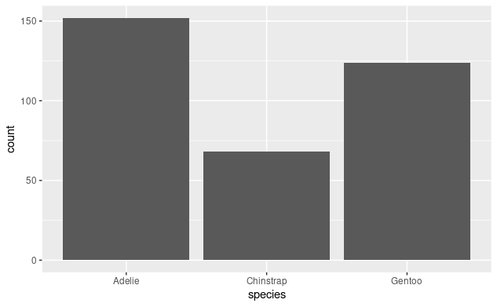

```r
penguins %>%
  ggplot(aes(x = species)) +
  geom_bar()
```

Qual foi a espécie mais numerosa e qual foi a mais rara?

## 1.2 **Número de indivíduos por espécie e por gênero**

Uma das vantagens do `ggplot2` é a facilidade em adicionar novas informações aos gráficos a partir do mapeamento de elementos estéticos. Adicione ao seu gráfico de barras informações sobre o sexo dos pinguins de cada espécies.

- Selecione as variáveis (colunas) `species` e `sex` utilizando a função select;
- Atribua a variável `sex` ao estético `fill` para gerar barras empilhadas de diferentes cores que indicam o número de pinguins amostrados para cada sexo e para cada espécie.

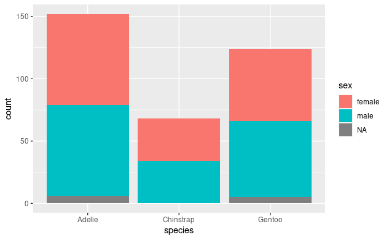

```r
penguins %>%
  ggplot(aes(x = species, fill = sex)) +
  geom_bar()
```

- Note que uma variável indesejada, `NA`, foi adicionada ao seu gráfico. Resolva esse problema aplicando a função `drop_na()` logo após a seleção das variáveis.

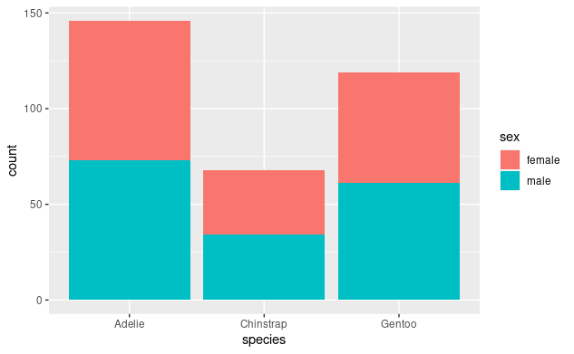

```r
penguins %>%
  select(species, sex) %>%
  drop_na() %>%
  ggplot(aes(x = species, fill = sex)) +
  geom_bar()
```

Outra forma de visualizar o número de pinguins machos e fêmeas amostrados para cada espécie é utilizando barras lado a lado. Isso é possível alterando o *default* do atributo geométrico `position = "stack"` da camada geométrica do gráfico.

- atribua a posição `"dodge"` ao atributo geométrico `position =` dentro da camada geométrica `geom_bar()`.

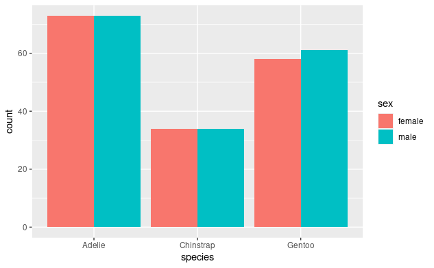

```r
penguins %>%
  select(species, sex) %>%
  drop_na() %>%
  ggplot(aes(x = species, fill = sex)) +
  geom_bar(position = "dodge")
```

Outra característica do seu gráfico que pode ser alterada a partir de um atributo geométrico é a cor das bordas das barras.

- adicione bordas pretas as barras do seu gráfico atribuindo a cor `"black"` ao atributo geométrico `color =` dentro da função `geom_bar()`.

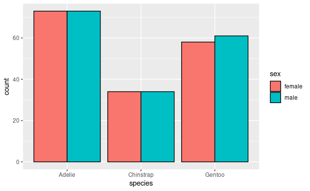

```r
penguins %>%
  select(species, sex) %>%
  drop_na() %>%
  ggplot(aes(x = species, fill = sex)) +
  geom_bar(position = "dodge",
           color = "black")
```

## 1.3 **Modificando os eixos do gráfico**

O pacote `ggplot2` gera uma versão customizada de gráfico, mas permite um controle absoluto de todas as suas características. Vamos começar a alterar aspectos dos eixos para personalizar a aparência do seu gráfico até que vocÊ gere uma versão apropriada para uso e divulgação.

- Seu gráfico não possui eixos. Adicione uma linha horizontal para representar o eixo x utilizando a função a camada geométrica `geom_hline(yintercept = 0)`.

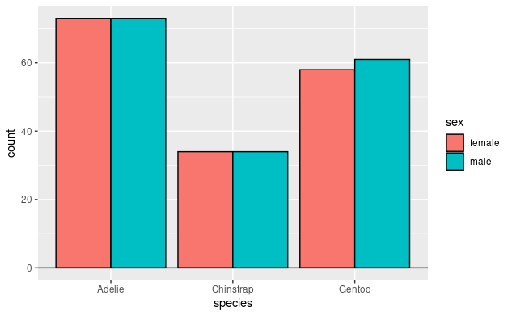

```r
penguins %>%
  select(species, sex) %>%
  drop_na() %>%
  ggplot(aes(x = species, fill = sex)) +
  geom_bar(position = "dodge",
           color = "black") +
  geom_hline(yintercept = 0)
```

- Agora que você adicionou a linha do eixo x, você pode corrigir o título desse eixo. Para deixar o título do eixo x com a primeira letra maiúscula, adicione a camada de mapeamento estético `scale_x_discrete("Species")` ao final do seu código.

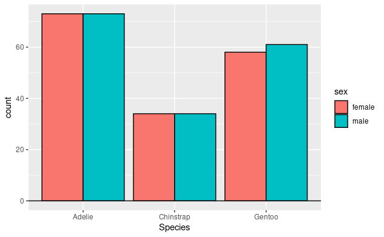

```r
penguins %>%
  select(species, sex) %>%
  drop_na() %>%
  ggplot(aes(x = species, fill = sex)) +
  geom_bar(position = "dodge",
           color = "black") +
  geom_hline(yintercept = 0) +
  scale_x_discrete("Species")
```

- O título do eixo y também precisa ser modificado. Para isso, adicione a camada estética scale_y_continuous(“Number of penguins”) ao final do seu código;
- Para ter um maior controle dos rótulos do eixo y, utilize o argumento breaks = seq(0, 80, 10) e compare com os valores plotado neste eixo no gráfico anterior.

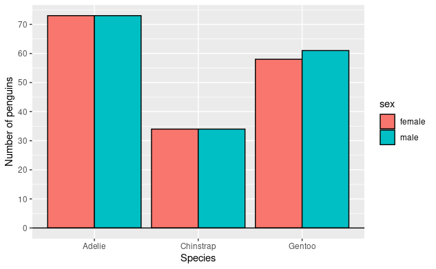

```r
penguins %>%
  select(species, sex) %>%
  drop_na() %>%
  ggplot(aes(x = species, fill = sex)) +
  geom_bar(position = "dodge",
           color = "black") +
  geom_hline(yintercept = 0) +
  scale_x_discrete("Species") +
  scale_y_continuous("Number of penguins",
                     breaks = seq(0, 80, 10))
```

- Ainda é necessário alterar o título da legenda, dos seus rótulos e as cores das barras. Você pode realizar essas alterações utilizando `scale_fill_dsicrete("Sex", type = c("black", "dark grey"), labels = c("Female", "Male"))`;
- Gráficos para publicação em periódicos científicos impressos devem ser coloridos em escala de cinza. Contudo, atualmente muitas publicações também são disponibilizadas onlie e permitem gráficos coloridos. Experimente alterar as cores das barras do seu gráfico, alterando as cores fornecidas no argumento `type =`;
- Experimente trocar a camada `scale_fill_dsicrete()` pela camada `scale_fill_brewer()`;
- Experimente alterar o argumento `pelette =`, por exemplo `palette = "Dark2"`
- Consulte o `help()` da camada `scale_fill_brewer()` para conhecer melhor seu funcionamento e expandir sua capacidade de gerar gráficos de barra bem coloridos.

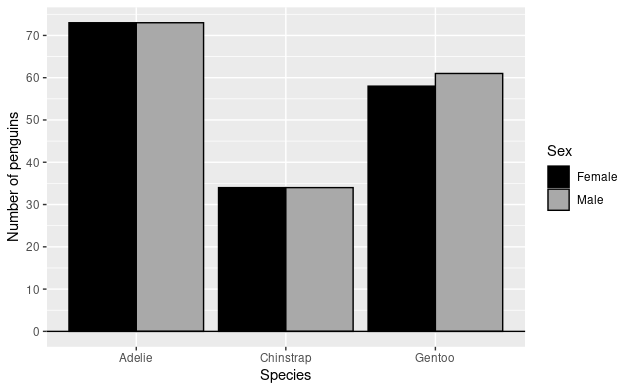

## 1.4 **Salvando o gráfico como um objeto**

Os gráficos gerados a partir do `ggplot2` podem ser salvos em objetos, os quais podem ser utilizados para adicionar novas camadas. Veja este exemplo:

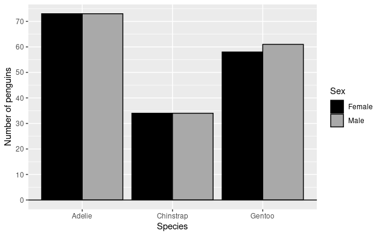

- Armazene o gráfico que você produziu até aqui em um objeto chamado `n_pinguins_sp`.

```r
n_pinguins_sp <- penguins %>%
  select(species, sex) %>%
  drop_na() %>%
  ggplot(aes(x = species, fill = sex)) +
  geom_bar(position = "dodge",
           color = "black") +
  geom_hline(yintercept = 0) +
  scale_x_discrete("Species") +
  scale_y_continuous("Number of penguins",
                     breaks = seq(0, 80, 10)) +
  scale_fill_discrete("Species",
                      type = c("black", "dark grey"),
                      labels = c("Female", "Male"))
```

## 1.5 **Modificando a aparência do gráfico a partir da camada `theme()` 1 - alterando elementos de texto**

A camada `theme()` é reponsável por controlar todos os elementos gráficos não relacionados aos dados, como elementos de texto, de linhas e de formas retangulares. Primeiramente, você irá efetuar as alterações necessárias em toda a parte de texto do seu gráfico.

- Altere o tipo da fonte atribuindo a função `element_text(family = "serif")` ao argumento `text =`;
- Aumente o tamanho da fonte dos títulos dos eixos e deixe-os em negrito atribuindo a função `element_text(face = "bold", size = 24)` ao argumento `axis.title =`.

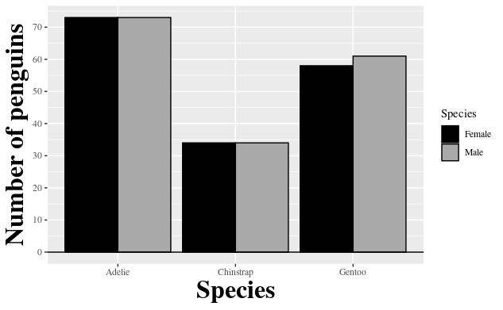

```r
n_pinguins_sp +
  theme(text = element_text(family = "serif"),
        axis.title = element_text(face = "bold",
                                 size = 24))
```

- Altere o tamanho dos rótulos dos eixos atribuindo a função `element_text(size = 18)` ao argumento `axis.text =`.

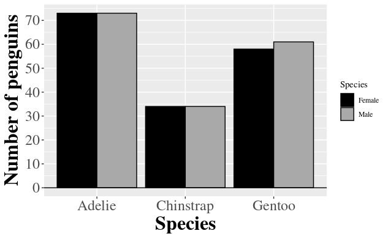

```r
n_pinguins_sp +
  theme(text = element_text(family = "serif"),
        axis.title = element_text(face = "bold",
                                 size = 24),
        axis.text = element_text(size = 18))
```

- Altere o tamanho do título da legenda e deixe-o em negrito atribuindo a função `element_text(size = 20, face = "bold")` ao argumento `legend.title =`.

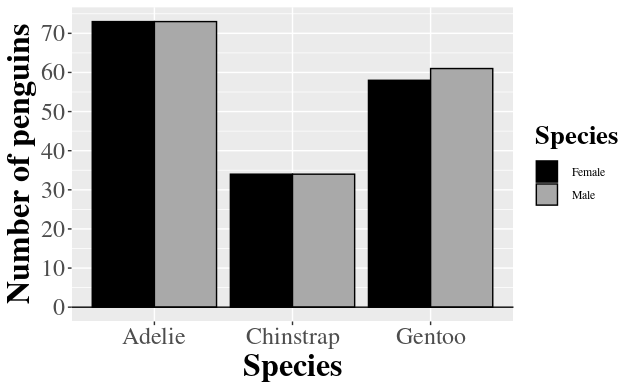

```r
n_pinguins_sp +
  theme(text = element_text(family = "serif"),
        axis.title = element_text(face = "bold",
                                 size = 24),
        axis.text = element_text(size = 18),
        legend.title = element_text(size = 20,
                                    face = "bold"))
```

- Aumente o tamanh oda fonte dos rótulos da legenda aplicando a função `element_text(size = 18)` ao argumento `legend.text =`.

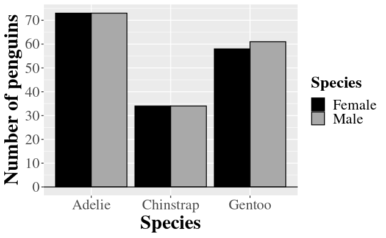

```r
n_pinguins_sp +
  theme(text = element_text(family = "serif"),
        axis.title = element_text(face = "bold",
                                 size = 24),
        axis.text = element_text(size = 18),
        legend.title = element_text(size = 20,
                                    face = "bold"),
        legend.text = element_text(size = 18))
```

## 1.6 **Modificando a aparência do gráfico a partir da camada `theme()` 2 - alterando elementos de linha**

- Adicione a linha do eixo y aplicando a função `element_line()` ao argumento `axis.line.y =` para adicionar a linha do eixo y.

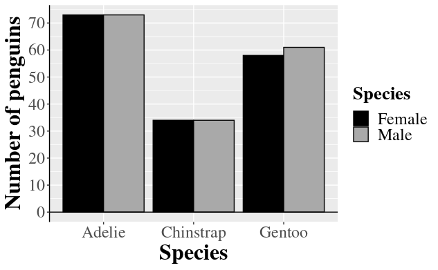

```r
n_pinguins_sp +
  theme(text = element_text(family = "serif"),
        axis.title = element_text(face = "bold",
                                 size = 24),
        axis.text = element_text(size = 18),
        legend.title = element_text(size = 20,
                                    face = "bold"),
        legend.text = element_text(size = 18),
        axis.line.y = element_line())
```

- Exclua os *ticks* do eixo x aplicando a função `element_blanck()` ao argumento `axis.ticks.x =`.

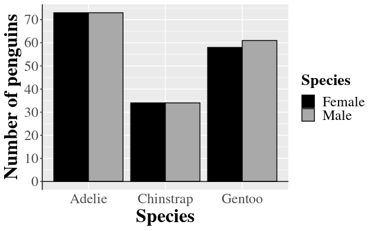

## 1.7 **Modificando a aparência do gráfico a partir da camada `theme()` 3 - alterando elementos retangulares**

- Oculte o fundo acinzentado do gráfico aplicando a função `element_blanck()` ao argumento `panel.background =`.

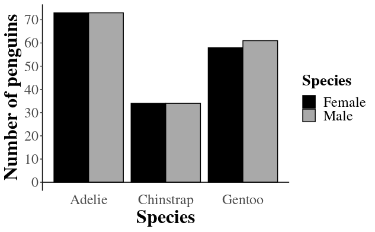

```r
n_pinguins_sp +
  theme(text = element_text(family = "serif"),
        axis.title = element_text(face = "bold",
                                 size = 24),
        axis.text = element_text(size = 18),
        legend.title = element_text(size = 20,
                                    face = "bold"),
        legend.text = element_text(size = 18),
        axis.line.y = element_line(),
        axis.ticks.x = element_blank(),
        panel.background = element_blank())
```

## 1.8 **Salvando o tema como um objeto**

Como você viu no exercício 1.4, é possível gravar as camadas gráficas do `ggplot2` em um objeto para reutilizá-lo. Da mesma forma, é possível gravar uma camada de tema personalizada para reutilizá-la em outros gráficos.

- Armazene a camada final de tema que você produziu no último item do exercício 1.7 num objeto chamado `meu_tema_barras`.

```r
meu_tema_barras <- theme(text = element_text(family = "serif"),
        axis.title = element_text(face = "bold",
                                 size = 24),
        axis.text = element_text(size = 18),
        legend.title = element_text(size = 20,
                                    face = "bold"),
        legend.text = element_text(size = 18),
        axis.line.y = element_line(),
        axis.ticks.x = element_blank(),
        panel.background = element_blank())
```

Imprima o seu gráfico de barras utilizando as camadas gráficas que você armazenou no objeto `n_pinguins_sp` e `meu_tema_barras`.

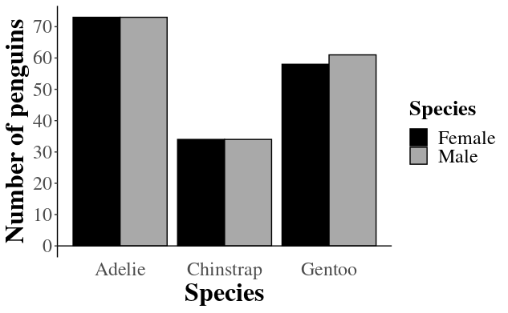

```r
n_pinguins_sp +
  meu_tema_barras
```

Há alguma diferença aparente no número de indivíduos fêmeas e macho capturados para cada espécie?

# 2 **Visualizando a distribuição de frequências da massa dos pinguins**

Agora você irá visualizar a distribuição de frequências da massa dos pinguins do arquipélogo Plamer.

- Selecione as colunas `species`e `body_mass_g` e certifique-se de que você descartou os valores ausentes (`NA`) utiliznado a função `drop_na()`;
- Aplique o estético `x = body_mass_g` a função `ggplot(aes())`;
- Adicione a camada geométrica `geom_histogram()`

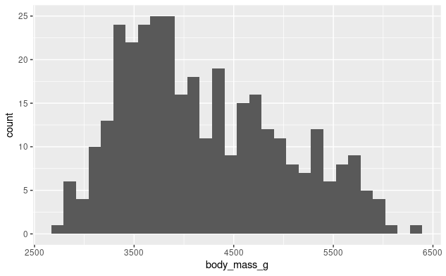

```r
penguins %>%
  select(species, body_mass_g) %>%
  drop_na() %>%
  ggplot(aes(x = body_mass_g)) +
  geom_histogram()
```

- Aplique o atributo geométrico `binwidth = 200` para a ajustar a largura das barras.

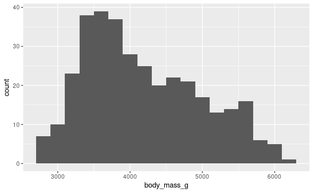

```r
penguins %>%
  select(species, body_mass_g) %>%
  drop_na() %>%
  ggplot(aes(x = body_mass_g)) +
  geom_histogram(binwidth = 200)
```

- Aplique o atributo geométrico `center = 100` para ajustar a posição dos *ticks* no eixo x.

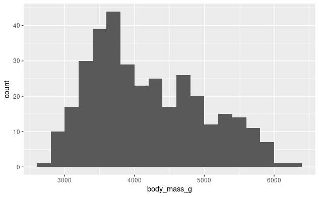

## 2.1 **Distribuição de frequências da massa por espécie de pinguim**

Você acabou de gera visualizações da distribuição de frequências da massa de pinguins relativa a toda a sua população amostral. Contudo,há três populações biológicas distintas na amostra. Agora, você irá gerar um gráfico de com a distribuição de frequência das massas para cada uma das espécies.

- Adicione o mapeamento estético `fill = species` a camada `ggplot(aes())`.

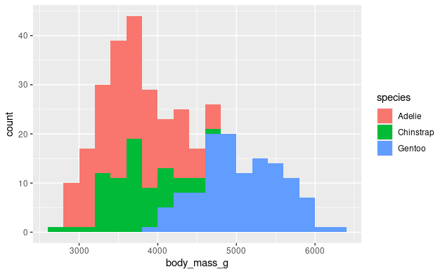

```r
penguins %>%
  select(species, body_mass_g) %>%
  drop_na() %>%
  ggplot(aes(x = body_mass_g,
             fill = species)) +
  geom_histogram(binwidth = 200,
                 center = 100)
```

- Adicione um grau de transparência às barras aplicando o atributo geométrico `alpha = 0.5` acamada geomrica `geom_histogram()`.

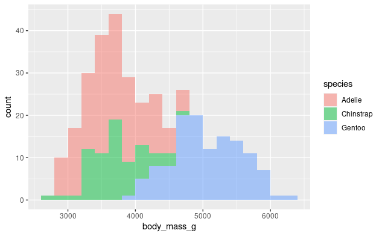

```r
penguins %>%
  select(species, body_mass_g) %>%
  drop_na() %>%
  ggplot(aes(x = body_mass_g,
             fill = species)) +
  geom_histogram(binwidth = 200,
                 center = 100,
                 alpha = 0.5)
```

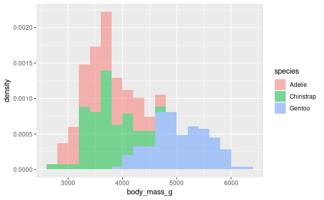

## 2.2 **Modificando os eixos do gráfico**

Assim como o gráfico de barras, seu não possui eixos. Adicione uma linha horizontal para representar o eixo x utilizando a função a camada geométrica `geom_hline(yintercept = 0)`.

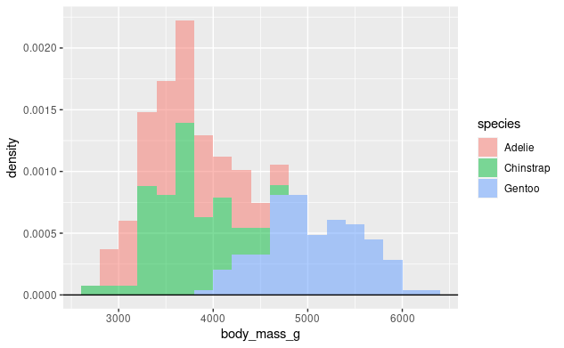

- Altere o título do eixo x para que ele fique com a primeira letra maiúscula, adicionando a camada de mapeamento estético `scale_x_continuous("Body mass (g")` ao final do seu código.

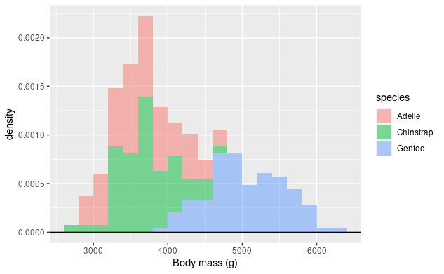

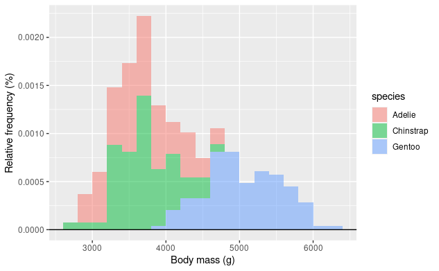

- Ainda é necessário alterar o título da legenda e as cores das barras. Você pode realizar essas alterações utilizando `scale_fill_dsicrete("Species", type = c("black", "grey40", "dark grey"))`

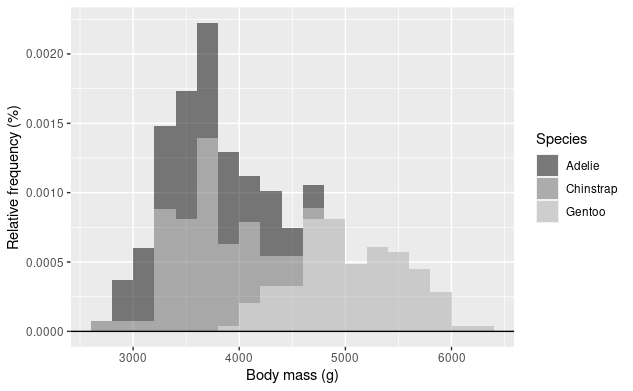

- Experimente trocar a camada `scale_fill_dsicrete()` pela camada `scale_fill_brewer()`;
- Experimente alterar o argumento `pelette =`, por exemplo `palette = "Dark2"`
- Consulte o `help()` da camada `scale_fill_brewer()` para conhecer melhor seu funcionamento e expandir sua capacidade de gerar gráficos de barra bem coloridos.

## 2.3 **Salvando o gráfico como um objeto**

-Armazene o gráfico que você produziu até aqui em um objeto chamado `body_mass_histogram`

## 2.4 **Alterando a aprência do gráfico utilizando o `meu_tema_barras`**

- Imprima o seu gráfico de barras utilizando as camadas gráficas que você armazenou no objeto `body_mass_histogram` e `meu_tema_barras`.

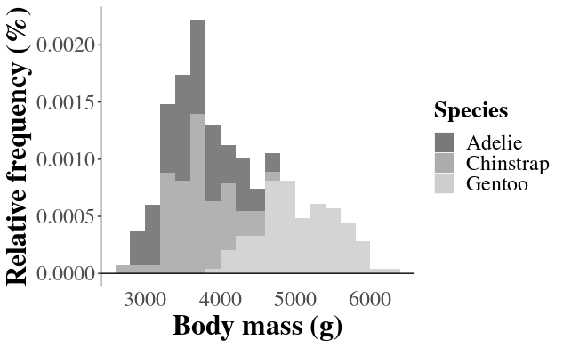

Qual é a espécie de pinguim mais pesada?

ÉE possível identificar uma espécie mais leve a partir das distribuições de frequência de massa dos pinguins?

# 3 **Visualizando a relação entre o comprimento e a largura do bico dos pinguins**

## 3.1 **Relação comprimento x largura do bico**

Agora você irá avalia a relação entre o comprimento e a largura do bico dos pinguins do arquipélogo Palmers. Esta relação é importante pois diferenças entre as espécies podem ser sugestivas de diferenças tróficas entre elas.

- Selecione as variáveis `species`, `bill_length_mm` e `bill_depth_mm` utilizando a função `select()`;
- Lembre-se de descartar valores ausentes (`NA`) aplicando a função `drop_na()`;
- Aplique os estético `x = bill_depth_mm` e `y = bill_length_mm` na camada `ggplot(aes())`;
- Ao final, adicione a camada geom_point().

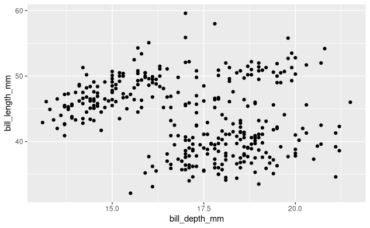

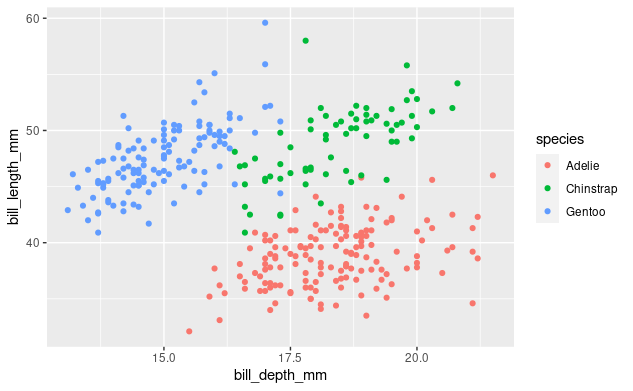

Altere os símbolos

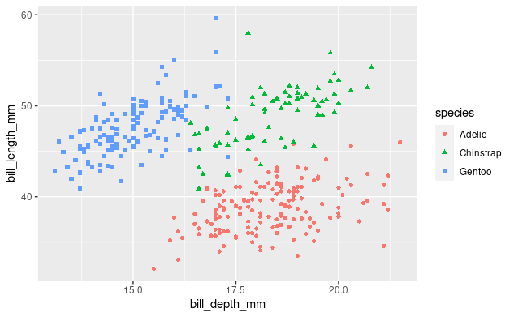